# An Introduction to Tree-Based Regression Methods

### STAT 527 - Jingbo Liu - Fall 2021

### Author: Gabe Taylor

# Agenda

### Data Overview ~ 5 mins

- Problem presentation/data description ~ 2 mins
- Exploratory Data Analysis (EDA) ~ 2 mins
- Data Preprocessing ~ 1 min

### Modeling ~ 25 mins

- Cross-Validation ~ 3 mins
- **OLS & Lasso** ~ 3 mins
- **Decision Trees** ~ 5 mins
- **Random Forest** ~ 5 mins
- **Gradient boosting** ~ 7 mins
- Variable Importances ~ 1 min
- Partial Dependence ~ 1 min

# Data Description

[figure not shown]

|  | school | sex | age | address | famsize | Pstatus | Medu | Fedu | Mjob | Fjob | ... | famrel | freetime | goout | Dalc | Walc | health | absences | G1 | G2 | G3 |
| --- | --- | --- | --- | --- | --- | --- | --- | --- | --- | --- | --- | --- | --- | --- | --- | --- | --- | --- | --- | --- | --- |
| 0 | GP | F | 18 | U | GT3 | A | 4 | 4 | at_home | teacher | ... | 4 | 3 | 4 | 1 | 1 | 3 | 6 | 5 | 6 | 6 |
| 1 | GP | F | 17 | U | GT3 | T | 1 | 1 | at_home | other | ... | 5 | 3 | 3 | 1 | 1 | 3 | 4 | 5 | 5 | 6 |
| 2 | GP | F | 15 | U | LE3 | T | 1 | 1 | at_home | other | ... | 4 | 3 | 2 | 2 | 3 | 3 | 10 | 7 | 8 | 10 |
| 3 | GP | F | 15 | U | GT3 | T | 4 | 2 | health | services | ... | 3 | 2 | 2 | 1 | 1 | 5 | 2 | 15 | 14 | 15 |
| 4 | GP | F | 16 | U | GT3 | T | 3 | 3 | other | other | ... | 4 | 3 | 2 | 1 | 2 | 5 | 4 | 6 | 10 | 10 |
| ... | ... | ... | ... | ... | ... | ... | ... | ... | ... | ... | ... | ... | ... | ... | ... | ... | ... | ... | ... | ... | ... |
| 390 | MS | M | 20 | U | LE3 | A | 2 | 2 | services | services | ... | 5 | 5 | 4 | 4 | 5 | 4 | 11 | 9 | 9 | 9 |
| 391 | MS | M | 17 | U | LE3 | T | 3 | 1 | services | services | ... | 2 | 4 | 5 | 3 | 4 | 2 | 3 | 14 | 16 | 16 |
| 392 | MS | M | 21 | R | GT3 | T | 1 | 1 | other | other | ... | 5 | 5 | 3 | 3 | 3 | 3 | 3 | 10 | 8 | 7 |
| 393 | MS | M | 18 | R | LE3 | T | 3 | 2 | services | other | ... | 4 | 4 | 1 | 3 | 4 | 5 | 0 | 11 | 12 | 10 |
| 394 | MS | M | 19 | U | LE3 | T | 1 | 1 | other | at_home | ... | 3 | 2 | 3 | 3 | 3 | 5 | 5 | 8 | 9 | 9 |

395 rows × 33 columns

# EDA

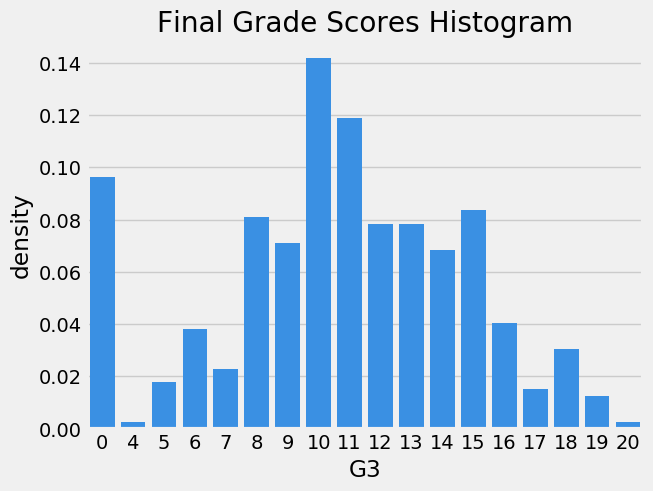

## Final Grade Distribution by Feature

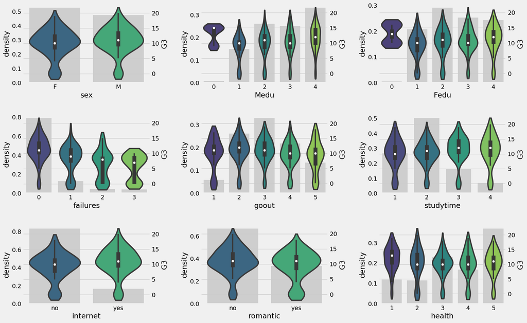

# Heatmap of Average Final Grade by Previous Grades

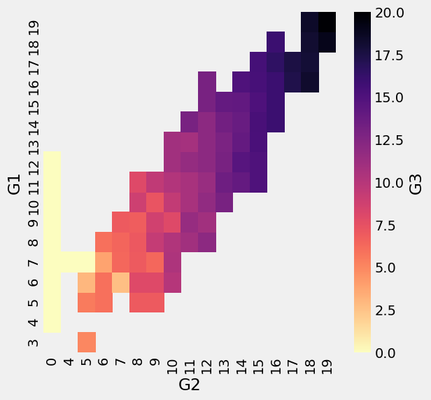

# Data Pre-processing

## One-Hot Encoding

Dropped reference level in order to avoid dummy-variable trap

|  | school_MS | sex_M | address_U | famsize_LE3 | Pstatus_T | Medu_1 | Medu_2 | Medu_3 | Medu_4 | Fedu_1 | ... | Dalc_4 | Dalc_5 | Walc_2 | Walc_3 | Walc_4 | Walc_5 | health_2 | health_3 | health_4 | health_5 |
| --- | --- | --- | --- | --- | --- | --- | --- | --- | --- | --- | --- | --- | --- | --- | --- | --- | --- | --- | --- | --- | --- |
| 0 | 0 | 0 | 1 | 0 | 0 | 0 | 0 | 0 | 1 | 0 | ... | 0 | 0 | 0 | 0 | 0 | 0 | 0 | 1 | 0 | 0 |
| 1 | 0 | 0 | 1 | 0 | 1 | 1 | 0 | 0 | 0 | 1 | ... | 0 | 0 | 0 | 0 | 0 | 0 | 0 | 1 | 0 | 0 |
| 2 | 0 | 0 | 1 | 1 | 1 | 1 | 0 | 0 | 0 | 1 | ... | 0 | 0 | 0 | 1 | 0 | 0 | 0 | 1 | 0 | 0 |
| 3 | 0 | 0 | 1 | 0 | 1 | 0 | 0 | 0 | 1 | 0 | ... | 0 | 0 | 0 | 0 | 0 | 0 | 0 | 0 | 0 | 1 |
| 4 | 0 | 0 | 1 | 0 | 1 | 0 | 0 | 1 | 0 | 0 | ... | 0 | 0 | 1 | 0 | 0 | 0 | 0 | 0 | 0 | 1 |
| ... | ... | ... | ... | ... | ... | ... | ... | ... | ... | ... | ... | ... | ... | ... | ... | ... | ... | ... | ... | ... | ... |
| 390 | 1 | 1 | 1 | 1 | 0 | 0 | 1 | 0 | 0 | 0 | ... | 1 | 0 | 0 | 0 | 0 | 1 | 0 | 0 | 1 | 0 |
| 391 | 1 | 1 | 1 | 1 | 1 | 0 | 0 | 1 | 0 | 1 | ... | 0 | 0 | 0 | 0 | 1 | 0 | 1 | 0 | 0 | 0 |
| 392 | 1 | 1 | 0 | 0 | 1 | 1 | 0 | 0 | 0 | 1 | ... | 0 | 0 | 0 | 1 | 0 | 0 | 0 | 1 | 0 | 0 |
| 393 | 1 | 1 | 0 | 1 | 1 | 0 | 0 | 1 | 0 | 0 | ... | 0 | 0 | 0 | 0 | 1 | 0 | 0 | 0 | 0 | 1 |
| 394 | 1 | 1 | 1 | 1 | 1 | 1 | 0 | 0 | 0 | 1 | ... | 0 | 0 | 0 | 1 | 0 | 0 | 0 | 0 | 0 | 1 |

395 rows × 67 columns

# Mean Model

$$RMSE = \sqrt{\frac{1}{n} \sum_{i = 1}^n (y_i - \hat y_i)^2}$$

```
Mean Model RMSE: 4.576
```

# Cross-Validation

### 10 Fold Cross Validation

1. Split data into 10 folds
2. Reserve 1 fold for validation (scoring)
3. Train model on remaining 9 folds

[figure not shown]

### How to evaluate performance

One could take the average error over all of the folds:

[figure not shown]

Alternatively, one could append the cross-validation predictions to the original training data, and score the predictions using the the full training observations

[figure not shown]

### What about the Test Data?

- In practice, it is useful to score the final model on a holdout set in order to evaluate how well the the model will generalize to unseen data.
- In the project, due to the small training size, we will not reserve a portion of the data for a hold out, but instead, we will construct a 'test set' using the 10 folds as illustrated in the second method in previous slide.
- For consistency, this is default cross-validation scoring in H2o

# OLS Model

### Summary

```
Training RMSE: 3.672
Cross Validation RMSE: 4.544
```

|  | names | standardized_coefficients |
| --- | --- | --- |
| 0 | Intercept | 10.415190 |
| 51 | freetime_5 | 0.828484 |
| 31 | studytime_3 | 0.681765 |
| 52 | goout_2 | 0.668160 |
| 63 | Walc_5 | 0.633913 |
| ... | ... | ... |
| 11 | Fedu_2 | -0.992622 |
| 9 | Medu_4 | -1.230500 |
| 8 | Medu_3 | -1.636650 |
| 6 | Medu_1 | -1.669643 |
| 7 | Medu_2 | -1.835298 |

70 rows × 2 columns

# LASSO Model

### Summary

```
Training RMSE: 4.086
Cross Validation RMSE: 4.362
```

### Coefficients

|  | names | standardized_coefficients |
| --- | --- | --- |
| 0 | Intercept | 10.415190 |
| 1 | school_MS | 0.000000 |
| 2 | sex_M | 0.193052 |
| 3 | address_U | 0.034271 |
| 4 | famsize_LE3 | 0.072247 |
| ... | ... | ... |
| 65 | health_3 | 0.000000 |
| 66 | health_4 | 0.000000 |
| 67 | health_5 | 0.000000 |
| 68 | age | -0.064371 |
| 69 | absences | 0.007380 |

70 rows × 2 columns

|  | names | standardized_coefficients |
| --- | --- | --- |
| 0 | Intercept | 10.415190 |
| 1 | Medu_4 | 0.336882 |
| 2 | Mjob_services | 0.204124 |
| 3 | sex_M | 0.193052 |
| 4 | higher_yes | 0.168823 |
| 5 | studytime_3 | 0.118721 |
| 6 | goout_2 | 0.107856 |
| 7 | Mjob_health | 0.074712 |
| 8 | famsize_LE3 | 0.072247 |
| 9 | freetime_5 | 0.054082 |
| 10 | reason_reputation | 0.052682 |
| 11 | address_U | 0.034271 |
| 12 | freetime_2 | 0.030301 |
| 13 | absences | 0.007380 |
| 14 | internet_yes | 0.002141 |
| 15 | Medu_1 | -0.061367 |
| 16 | schoolsup_yes | -0.063288 |
| 17 | age | -0.064371 |
| 18 | goout_4 | -0.067517 |
| 19 | Dalc_2 | -0.077596 |
| 20 | goout_5 | -0.121048 |
| 21 | romantic_yes | -0.170427 |
| 22 | freetime_3 | -0.241182 |
| 23 | failures_3 | -0.604934 |
| 24 | failures_1 | -0.608071 |
| 25 | failures_2 | -0.621929 |

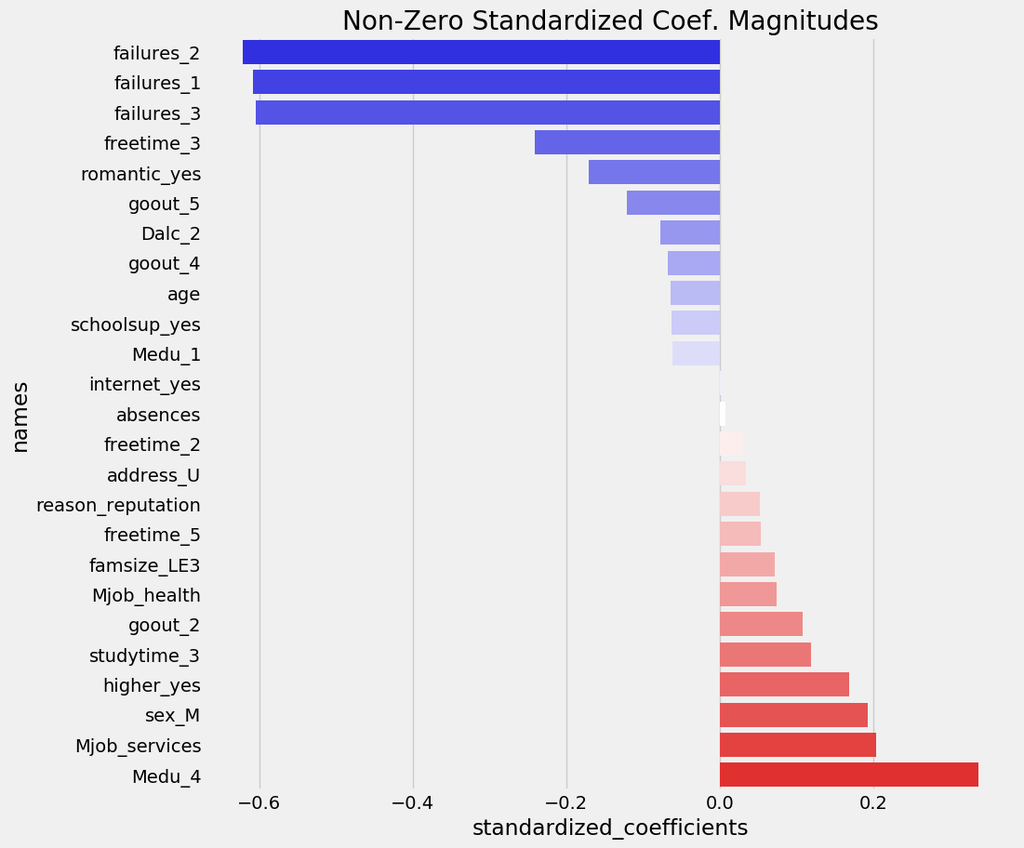

# Lambda Search

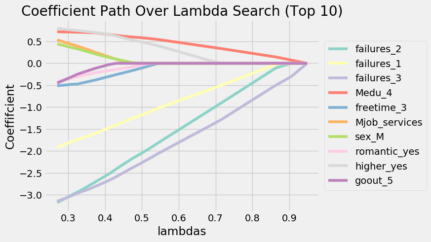

|  | Train RMSE | CV RMSE |
| --- | --- | --- |
| Mean | 4.576 | 4.576 |
| OLS | 3.672 | 4.544 |
| LASSO | 4.086 | 4.362 |

# Tree Based Learning

# Decision Tree Base Learner

# Why Trees?

### Pros

- Highly interpretable
- Interactions for free
- Natural handling of categorical predictors (no OHE required)
- No assumptions
- Missing Data handling
- Scale invariant (log-transforms or standardizations not required)

### Cons

- Individual trees empirically demonstrated to overfit easily (low bias, high variance)

[figure not shown]

[source](https://bradleyboehmke.github.io/HOML/DT.html)

[figure not shown]

[source](https://bradleyboehmke.github.io/HOML/DT.html)

# How to fit Regression Tree?

$$f(x) = \sum_{m=1}^M c_m I(x \in r_m)$$

Consider a splitting variable $j$ at split point $s$

$$R_1(j, s) = {X|X_j \leq s} \quad \text{and} \quad R_2(j, s) = {X|X_j > s}$$

Taking the loss function to be squared error, we want

$$\min_{j, s} \left[ \min_{c_1} \sum_{x_i \in R_1(j, s)} (y_i - c_1)^2 + \min_{c_2} \sum_{x_i \in R_1(j, s)} (y_i - c_2)^2 \right]$$

The inner minimization is solved with

$$\hat c_1 = \text{ave}(y_i |x_i \in R_1(j, s)) \quad \text{and} \quad \hat c_2 = \text{ave}(y_i |x_i \in R_2(j, s))$$

Search over the inputs for $j, s$ that yield

$$\min_{j, s} \left[ \sum_{x_i \in R_1(j, s)} (y_i - \bar y_i)^2 + \sum_{x_i \in R_1(j, s)} (y_i - \bar y_i)^2 \right]$$

Recursively perform the following until stopping criterion

```
At Parent Node:

    For j in variables

        For s in split points

            sum the loss in each side of the split

    Split the data at j, s such that the loss is minimized, where the split planes become parent nodes.
```

[figure not shown]

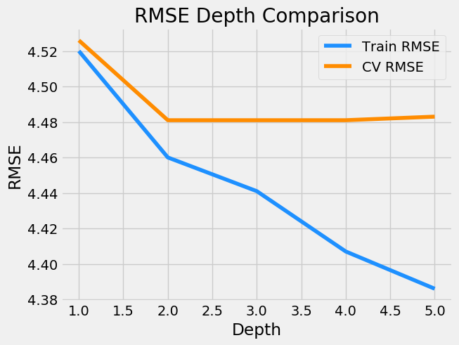

|  | Train RMSE | CV RMSE |
| --- | --- | --- |
| Mean | 4.576 | 4.576 |
| OLS | 3.672 | 4.544 |
| LASSO | 4.086 | 4.362 |
| Decision Tree | 4.46 | 4.481 |

# Random Forests

Ensemble of decorrelated trees

[figure not shown]

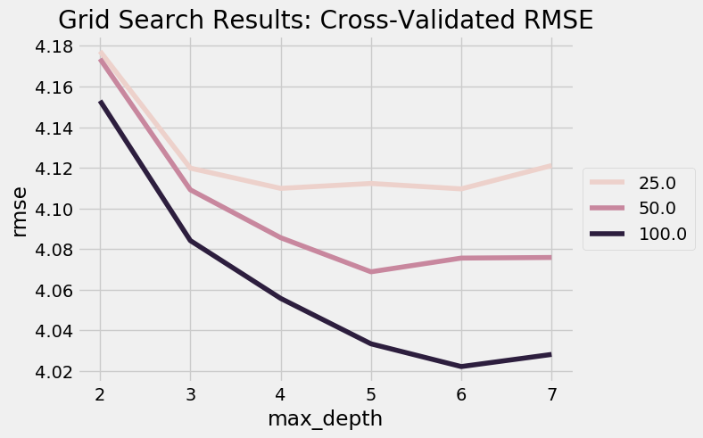

|  | Train RMSE | CV RMSE |
| --- | --- | --- |
| Mean | 4.576 | 4.576 |
| OLS | 3.672 | 4.544 |
| LASSO | 4.086 | 4.362 |
| Decision Tree | 4.46 | 4.481 |
| Random Forest | 4.001 | 4.022 |

# Gradient Boosting

### How to boost decision trees

Sequentially fitting additive decision trees in stagewise fashion.

[figure not shown]

$$\hat y_i ^{(0)} = \bar y$$$$\hat y_i ^{(1)} = f_1(x_i) + \hat y_i ^{(0)} = f_1(x_i) + \bar y$$$$\hat y_i ^{(2)} = f_2(x_i) + \hat y_i ^{(1)} = f_2(x_i) + f_1(x_i) + \bar y$$$$\dots$$$$\hat y_i ^{(t)} = \sum_{k=1}^t f_k(x_i) = f_t(x_i) + \hat y_i^{(t-1)}$$

[figure not shown]

Take

$$L(x, y) = 0.5(x - y)^2$$$$\frac{d}{dy}L(x, y) = -(x - y)$$

Then

$$r_{im} = -\left[\frac{d L(y_i, f(x_i)}{df(x_i} \right]_{f = f_{m-1}} = y_i - f_{m-1}(x_i)$$

Also

$$\gamma_{jm} = \arg \min_{\gamma} \sum_{x_i \in R_{jm}} L(y_i, f_{m-1}(x_i) + \gamma)$$

we can simply take

$$\frac{d}{d \gamma}\sum_{x_i \in R_{jm}} L(y_i, f_{m-1}(x_i) + \gamma)$$

$$\frac{d}{d \gamma}\sum_{x_i \in R_{jm}} 0.5(y_i - f_{m-1}(x_i) - \gamma)^2$$

$$= -\sum_{x_i \in R_{jm}} (y_i - f_{m-1}(x_i) - \gamma) = 0$$

$$= -\sum_{x_i \in R_{jm}} (r_{im} - \gamma) = 0$$

$$\gamma = \frac{1}{n_{jm}}\sum_{x_i \in R_{jm}} r_{im}$$

[figure not shown]

### Tuning

- Number of Trees (more trees -> overfit)
- Maximum Depth (deeper -> overfit)
- Learning Rate (larger -> overfit)
- Sampling Rates (larger -> overfit)
- Minimum Node Size (smaller -> overfit)

Use 10-fold cross validation to search for best parameters.

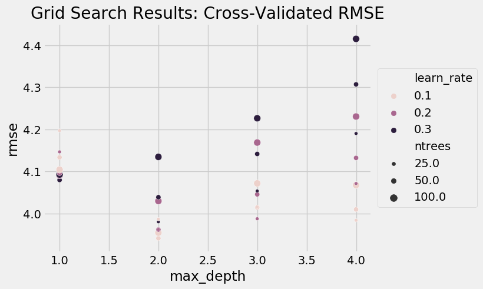

### Summary

|  | variable | scaled_importance |
| --- | --- | --- |
| 0 | failures | 1.000000 |
| 1 | absences | 0.866471 |
| 2 | freetime | 0.242512 |
| 3 | health | 0.188593 |
| 4 | Mjob | 0.146370 |
| 5 | Medu | 0.144549 |
| 6 | goout | 0.118127 |
| 7 | schoolsup | 0.093784 |
| 8 | Walc | 0.086578 |
| 9 | sex | 0.085563 |
| 10 | age | 0.082970 |

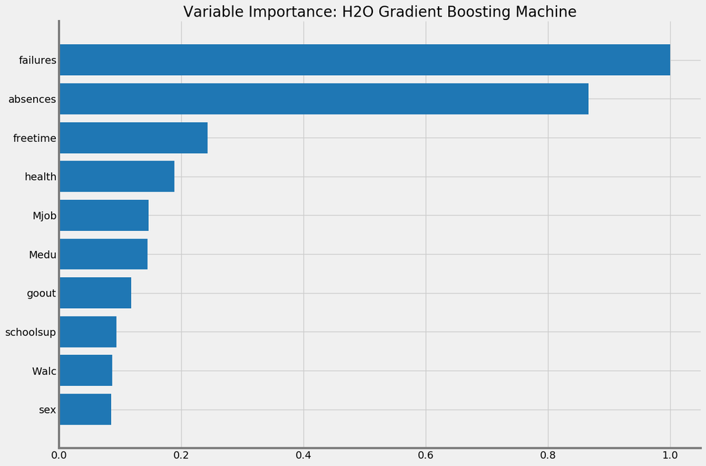

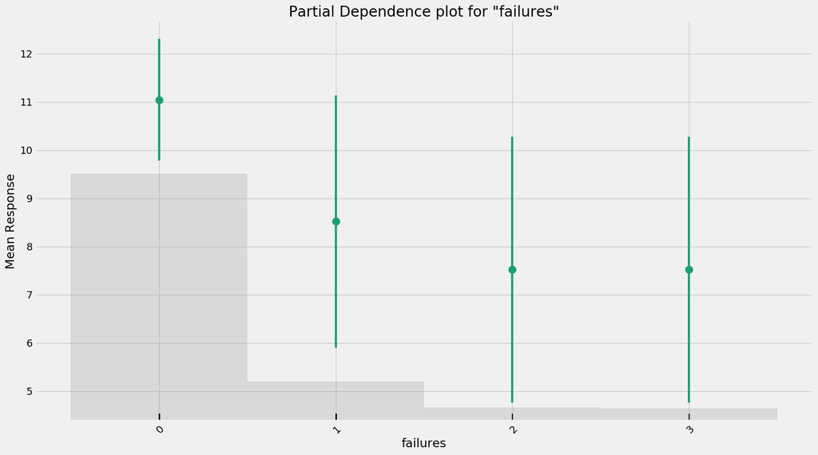

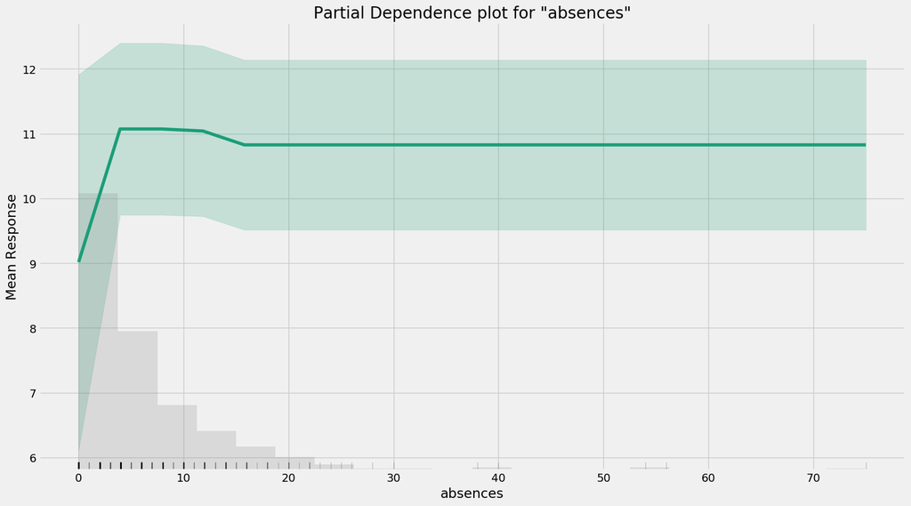

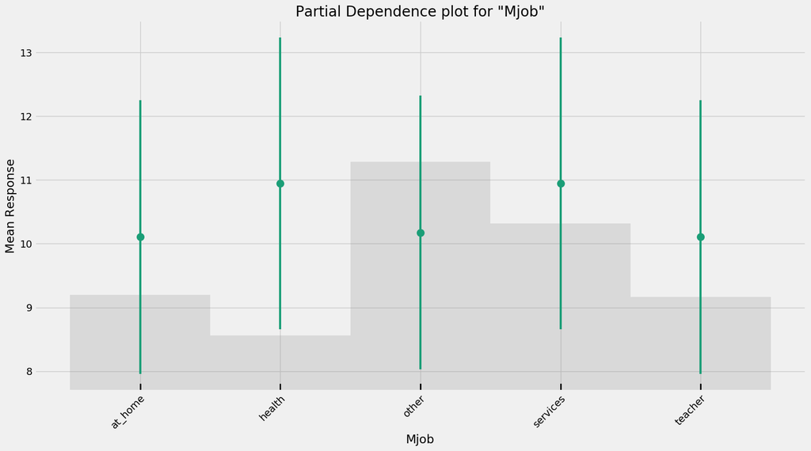

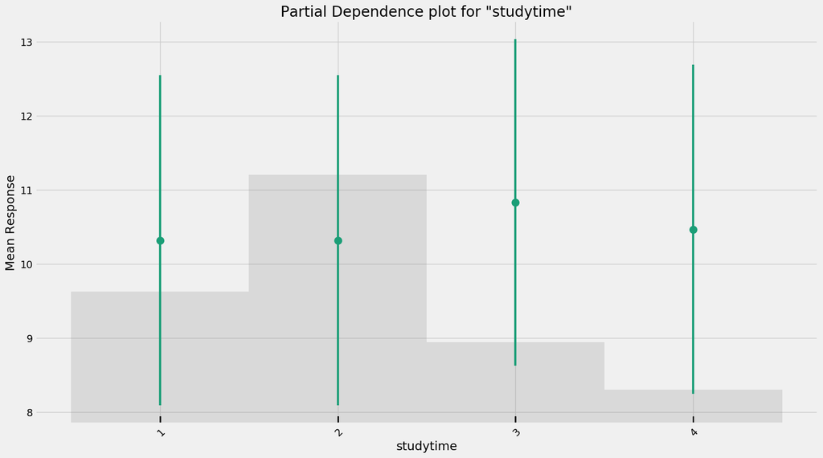

# Compare Models

|  | Train RMSE | CV RMSE |
| --- | --- | --- |
| Mean | 4.576 | 4.576 |
| OLS | 3.672 | 4.544 |
| LASSO | 4.086 | 4.362 |
| Decision Tree | 4.46 | 4.481 |
| Random Forest | 4.001 | 4.022 |
| GBM | 3.382 | 3.93 |

# Conclusion

My Github: https://github.com/gabeztaylor/STAT527

### Resources

Data Source: https://archive.ics.uci.edu/ml/datasets/student+performance

H2o Documentation: https://docs.h2o.ai/h2o/latest-stable/h2o-docs/data-science.html

ESL: https://web.stanford.edu/~hastie/ElemStatLearn/printings/ESLII_print12_toc.pdf

BSL: https://statisticallearning.org/

Hands-on Machine Learning: https://bradleyboehmke.github.io/HOML/gbm.html